# Lectura y Escritura de Datos

Junio, 2015

## Lectura de datos

[figure not shown]

- **R** puede acceder a información almacenada en distintos formatos:
  - Archivos de excel `.xls, .xlsx, .csv`,
  - Archivos de texto plano `.txt`,
  - Archivos de spss `.sav`,
  - Archivos de la web,
  - Archivos de bases de datos, etc.

## Path de un archivo

- Para construir el path o dirección en la pc de un conjunto de archivos utilizamos la función `file.path`.
  - `file.path` retorna un vector `character` de longitud `1`.

```r
file.path("C:","Users", "Source Stat Lab", "R Nivel Basico",
          fsep=.Platform$file.sep)
```

```
## [1] "C:/Users/Source Stat Lab/R Nivel Basico"
```

- Para considerar el path del archivo `data.xlsx` se debe añadir su nombre al final:

```r
file.path("C:","Users", "Source Stat Lab", "R Nivel Basico", "data.xlsx",
          fsep=.Platform$file.sep)
```

```
## [1] "C:/Users/Source Stat Lab/R Nivel Basico/data.xlsx"
```

`.Platform presenta una descripción de la plataforma utilizada`.

## Directorio de trabajo

- Working directory (`wd`). Es el path o la dirección donde se almacenan, leen y escriben los archivos utilizados y generados.
- `getwd()` permite obtener el `wd` actual:

```r
getwd()
```

```
## [1] "/Users/Diego/Dropbox/Source Stat Lab/Cursos/R Basico"
```

- `setwd()` permite setear un nuevo `wd`, por ejemplo:

```r
dir <- "C:/Source Stat Lab Ec/R Nivel Basico"
setwd(dir)
```

`Notar que se usa / en lugar de \`.

Importante diferencia en Windows

```r
setwd("C:\\Source Stat Lab Ec\\R Nivel Basico")
```

## Directorio de trabajo

- `list.files()` enlista los nombres de los archivos en el `wd` actual.

```r
list.files()
```

- El parámetro `pattern` se usa para enlistar los nombres de los archivos que contienen un determinado patrón.

```r
list.files(pattern = ".R")
```

```
##  [1] "alumnos_basic.Rnw"       "alumnos_grupo_2.Rnw"
##  [3] "data_str_04.Rmd"         "Ejercicios.R"
##  [5] "funcion_06.Rmd"          "install_02.Rmd"
##  [7] "interfaz_03.Rmd"         "intro_01.Rmd"
##  [9] "R Basico.Rproj"          "read_files_05.Rmd"
## [11] "Script_01.R"             "Script_06.R"
## [13] "Script_data_str_04.R"    "Script_readr_files_05.R"
```

## Directorio de trabajo

- `file.exists()` verifica si existe una carpeta con un determinado nombre en el `wd`.

```r
# Verifica si existe o no una carpeta con nombre "ssl"
file.exists("ssl")
```

```
## [1] TRUE
```

- `dir.create()` permite crear nuevas carpetas en el `wd`.

```r
# Crea una nueva carpeta con nombre "ssl"
dir.create("ssl")
```

`R sobreescribe una carpeta sobre otra, de ahí la importancia de utilizar previamente file.exists().`

## Lectura de archivos .txt

- Se requiere leer un archivo en formato txt: `data_read.txt`
- Se utiliza la función `read.table()`

```r
data_txt <- read.table(file = "data_read.txt",sep = "\t", dec = ",", header = TRUE)
dim(data_txt)
str(data_txt)
```

- Parámetros:
  - file: nombre del archivo (incluida extensión).
  - sep: caracter utilizado para separar columnas (variables).
  - dec: caracter utilizado para decimales.
  - header: `TRUE`, si la primera fila contiene los nombres de las columnas.
- `str()` describe la estructura de datos.

## Lectura de archivos .txt

```r
data_txt <- read.table(file = "data_read.txt",sep = "\t", dec = ",",
                       header = TRUE, stringsAsFactors = FALSE)
dim(data_txt)
str(data_txt)
```

## Lectura de archivos .csv

- Se requiere leer un archivo en formato csv: `data_read.csv`
- Se utiliza la función `read.table()`

```r
data_csv <- read.table(file = "data_read.csv",sep = ",", dec = ".", header = TRUE)
dim(data_csv)
str(data_csv)
```

- Parámetros:
  - file: nombre del archivo (incluida extensión).
  - sep: caracter utilizado para separa columnas.
  - dec: caracter utilizado para decimales.
  - header: `TRUE`, si la primera fila contiene los nombres de las columnas.
- Es posible utilizar:

```r
# en read.csv, por defecto, sep = ",", dec = ".", , header = TRUE
data_csv <- read.csv(file = "data_read.csv")
```

```r
data_csv2 <- read.csv2(file = "data_read.csv",sep = ",", dec = ".", header = TRUE)
```

## Lectura de archivos .xls, .xlsx

```r
install.packages("readxl", dependencies = TRUE)
library(readxl)
ls("package:readxl")
```

- **lista de las hojas** del libro "data_read.xlsx"

```r
# wd: directorio de trabajo actual
excel_sheets(path = file.path(wd, "data_read.xlsx"))
```

- **Lectura del archivo** `data_read.xlsx`

```r
data_xlsx <- read_excel("data_read.xlsx",sheet = "datos",col_names = TRUE, na="")
dim(data_xlsx)
```

- Parámetros:
  - sheet: Nombre de la hoja que contiene la data (recibe también número de hoja).
  - col_names: `TRUE` si la primera fila contiene los nombres de las columnas.
  - na: los caracteres que se coercionan a `NA`.

## Lectura de archivos .sav

- Se requiere leer archivos desde spss, es decir en formato sav: `data_read.sav`.
- Se utiliza la función `read.spss()` del paquete `foreign`.

```r
install.packages("foreign", dependencies = TRUE)
library(foreign)
ls("package:foreign")
```

```r
data_sav <- read.spss(file="data_read.sav", use.value.labels = TRUE,
                      to.data.frame = TRUE)
```

- Parámetros:
  - file: nombre del archivo (incluida extensión).
  - use.value.labels: `TRUE`, si se considerán las etiquetas de las variables.
  - to.data.frame: `TRUE`, para coercionar el archivo leído a data frame.

## Lectura de archivos .sav

- `haven` es un paquete publicado en el 2015 con caractaerísticas superiores a las del paquete `foreign`.
- Sus funciones de lectura son más eficientes.
- Permite leer archivos desde spss, stata, sas.

```r
install.packages("haven", dependencies = TRUE)
library(haven)
ls("package:haven")
```

- Para leer archivos en formato .sav se utiliza la función `read_spss()`.

```r
data_sav <- read_spss("data_read.sav")
```

- No requiere setear parámetros adicionales.
- Notar que se utiliza `_` en lugar de `.`

## foreign vs haven

- **Paquete foreign**

```r
system.time(data_sav1 <- read.spss("data_read.sav", use.value.labels = TRUE,
                                   to.data.frame = TRUE))
```

- **Paquete haven**

```r
system.time(data_sav2 <- read_spss("data_read.sav"))
```

- `system.time()` permite hacer una comparación en los tiempos utilizados por `read.spss()` y `read_spss()` al leer `data_read.sav`.

## Descargando datos desde la web

Cada día se multiplican los datos que pueden ser obtenidos desde la web, razón por la cual es importante contar con una herramienta que facilite el trabajo a al hora de acceder a dicha información.

La función `download.file()` permite descargar datos desde la web especificando 3 parámetros:

- **url:** Dirección web (debe iniciar con http o https).
- **destfile:** Lugar de la PC en la cual se almacenarán los datos.
- **method:** Define el metodo de descarga para sitios web con seguridad (https).

[figure not shown]

## Descargando datos desde la web

Obtenemos la url de la información y procedemos a descargar la misma dentro de la carpeta `ssl`, misma que creamos anteriormente.

```r
fileUrl <- "https://data.baltimorecity.gov/api/views/dz54-2aru/rows.csv?accessType=DOWNLOAD"
download.file(fileUrl, destfile = "./ssl/cameras.csv", method = "curl")
list.files("./ssl")
```

```
## [1] "cameras.csv"
```

```r
setwd("./ssl")
file.info("cameras.csv")
```

```
##             size isdir mode               mtime               ctime
## cameras.csv 9294 FALSE  644 2015-06-16 12:33:31 2015-06-16 12:33:31
##                           atime uid gid uname grname
## cameras.csv 2015-06-16 12:33:18 501  20 Diego  staff
```

Una vez descargada la información, usamos las funciones anteriores para cargar la data de acuerdo al formato obtenido.

## Lectura de archivos desde Dropbox

- Se requiere instalar el paquete `repmis`.

```r
install.packages("repmis", dependencies = TRUE)
library(repmis)
ls("package:repmis")
```

```r
data_dbx <- source_DropboxData(file = "data_read.txt", key="mk3y6070r51f9su", sep="\t",
                               header = TRUE)
```

- Parámetros:
  - file: nombre del archivo (incluida extensión).
  - key: key del archivo asignada por Dropbox.
  - sep: caracter utilizado para separar columnas.
  - header: `TRUE`, si la primera fila contiene los nombres de las columnas.

## Lectura de archivos desde tablas html

- Se requieren instalar los paquetes `RCurl y XML`.

```r
library(RCurl)
library(XML)
# install.packages("RCurl", dependencies = TRUE)
# install.packages("XML", dependencies = TRUE)
```

- `readHTMLTable()` permite leer una tabla de datos de una dirección Web.

```r
data_html <- readHTMLTable(url)
```

- Parámetros:
  - url: Dirección web de la tabla a leer `http://www.`.

## Gráficos estadísticos

- **R** es considerada como una de las herramientas más potentes para generar gráficos estadísticos, tales como:
  - Histogramas, Diagramas de densidad, Digramas de cajas,
  - Diagramas de dispersión, Diagramas de barras, etc.
- Dispone de tres sistemas **gráficos**: `base, lattice, ggplot`.
- En este caso estudiaremos únicamente el **sistema gráfico base**.

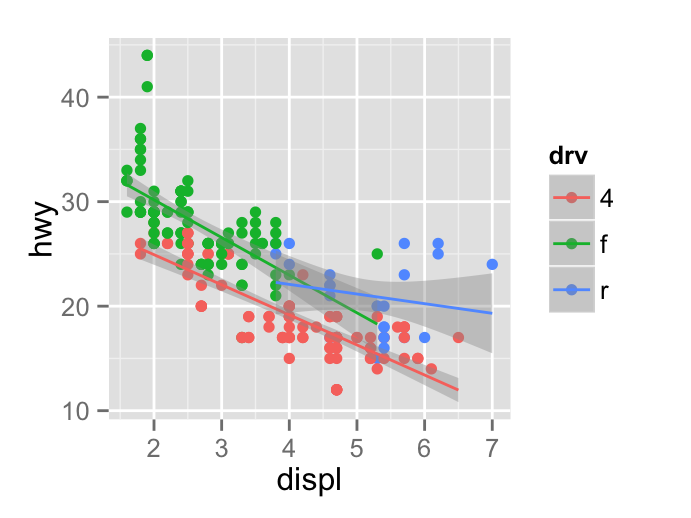

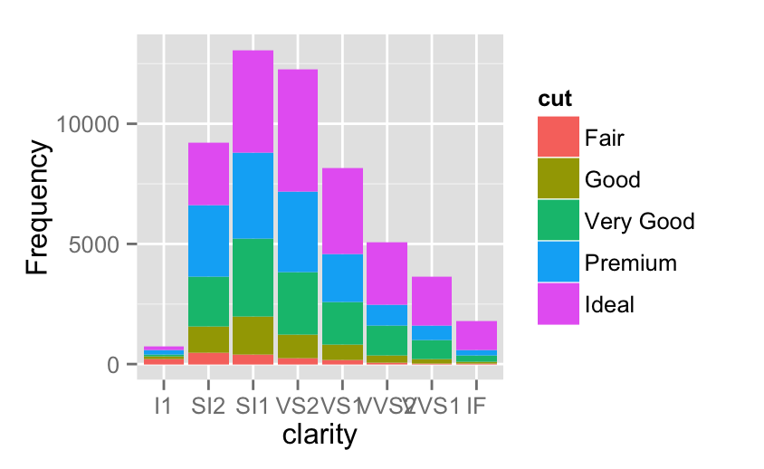

## Sistema gráfico "base"

- Se basa en la utilización de los paquetes:
  - `graphics`. Funciones gráficas `hist()`, `plot()`, etc.
  - `grDevices`. Funciones de dispositivos gráficos `pdf()`, `png()`, etc.
- **Características:**
- Modelo **paleta de artista**
  - Crear lienzo del gráfico con funciones de primer orden `plot()`, `hist()`, etc.
  - Añadir elementos utilizando funciones de segundo orden `lines()`, `points()`, etc.
- Muy intuitivo
- No posee un lenguaje gráfico estándar
- Llamado de varias funciones (códigos extensos)
- Una vez empezado el gráfico no es posible volver al inicio
- Permite fijar inicialmente layouts (margenes, espacios, etc) a través de la función `par()`

## histograma

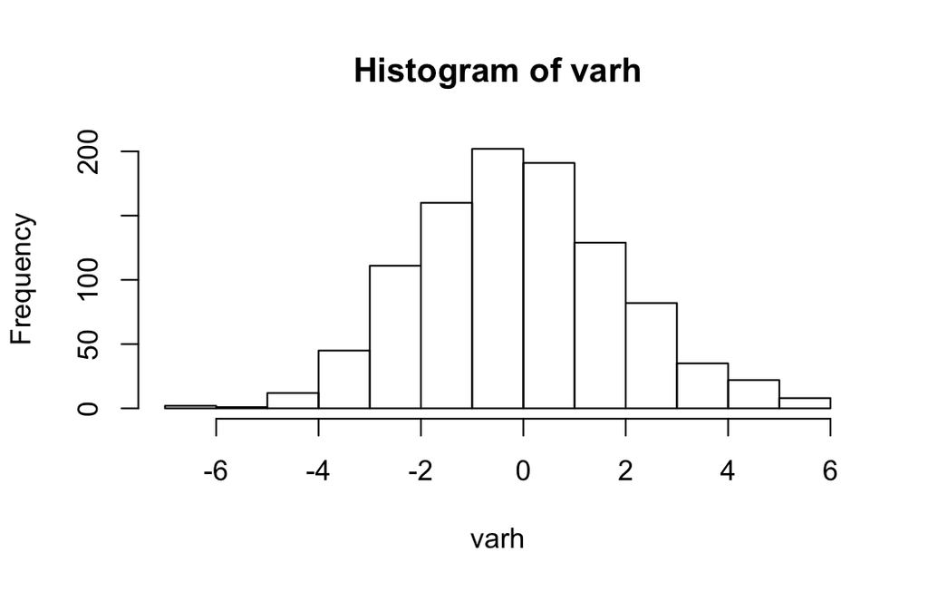

```r
varh <- rnorm(n = 1000, mean = 0, sd = 2)
hist(varh)
```

## histograma

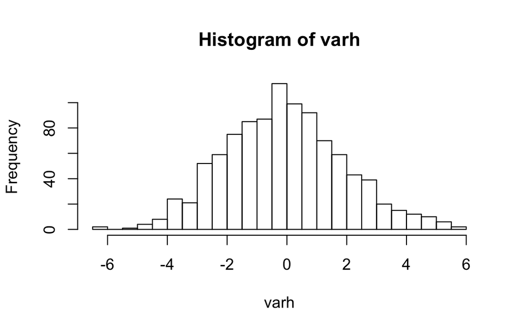

```r
hist(varh, breaks = 25)
```

## histograma

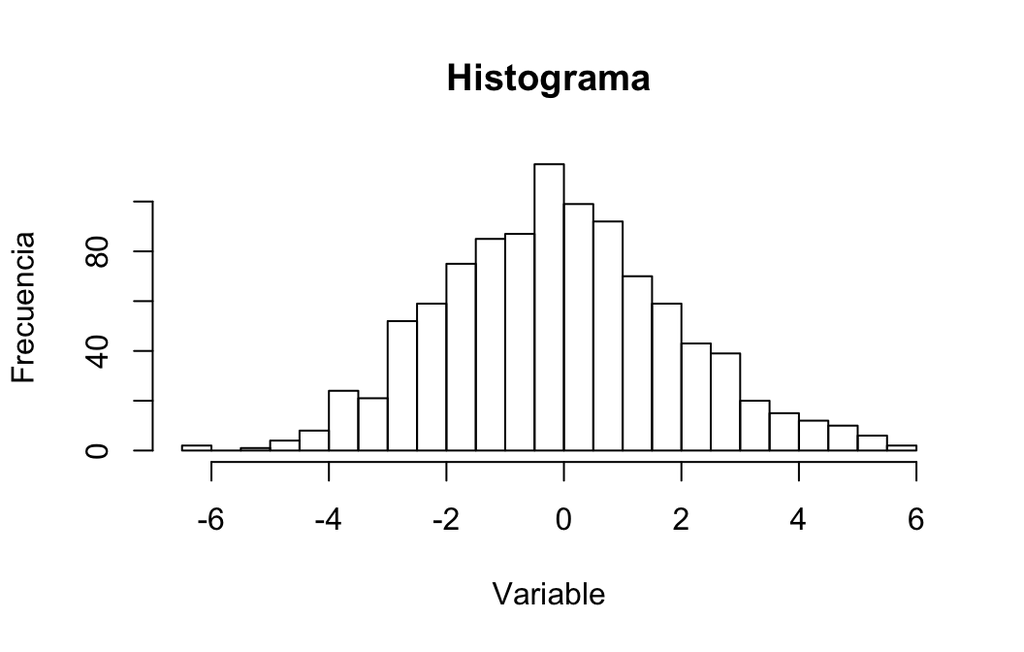

```r
hist(varh, breaks = 25, xlab = "Variable", ylab="Frecuencia", main="Histograma")
```

## histograma

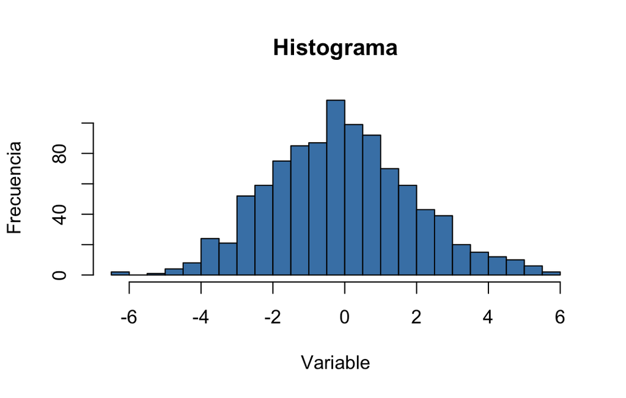

```r
hist(varh,breaks = 25, xlab = "Variable", ylab="Frecuencia", main="Histograma",
     col="steelblue", border="gray1")
```

## Diagrama de cajas

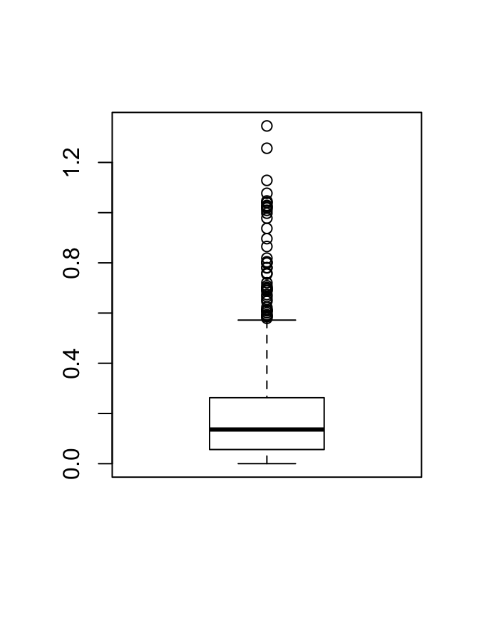

```r
varbx <- rexp(n = 1000, rate = 5)
boxplot(varbx)
```

## Diagrama de cajas

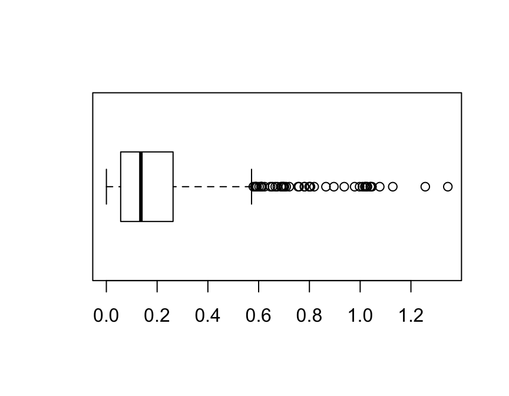

```r
boxplot(varbx, horizontal = TRUE)
```

## Diagrama de cajas

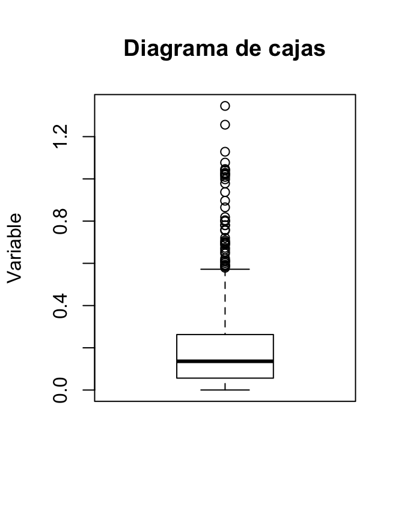

```r
boxplot(varbx, xlab = "", ylab="Variable", main="Diagrama de cajas")
```

## Diagrama de cajas

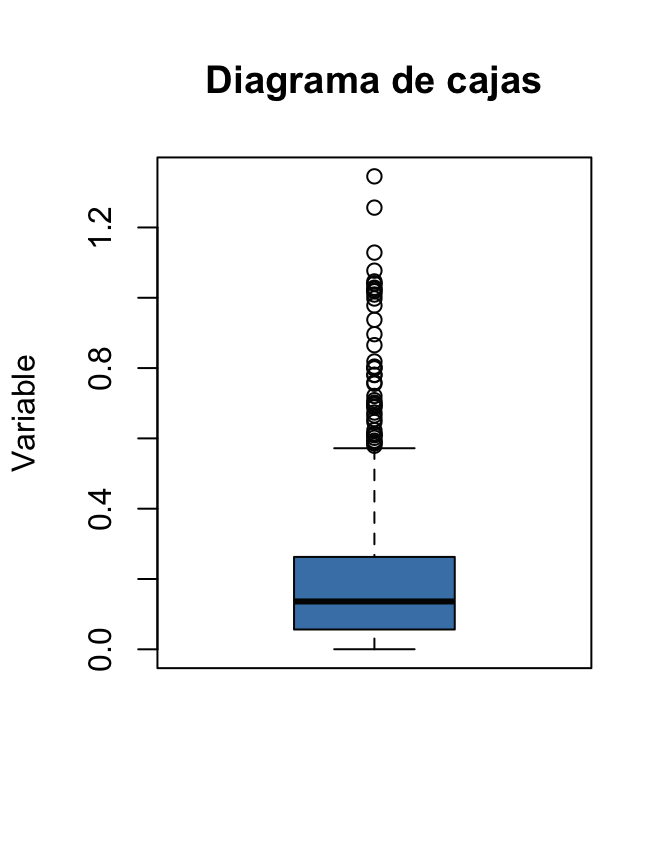

```r
boxplot(varbx, xlab = "", ylab="Variable", main="Diagrama de cajas",
     col="steelblue", border="gray1")
```

## Diagrama de dispersión

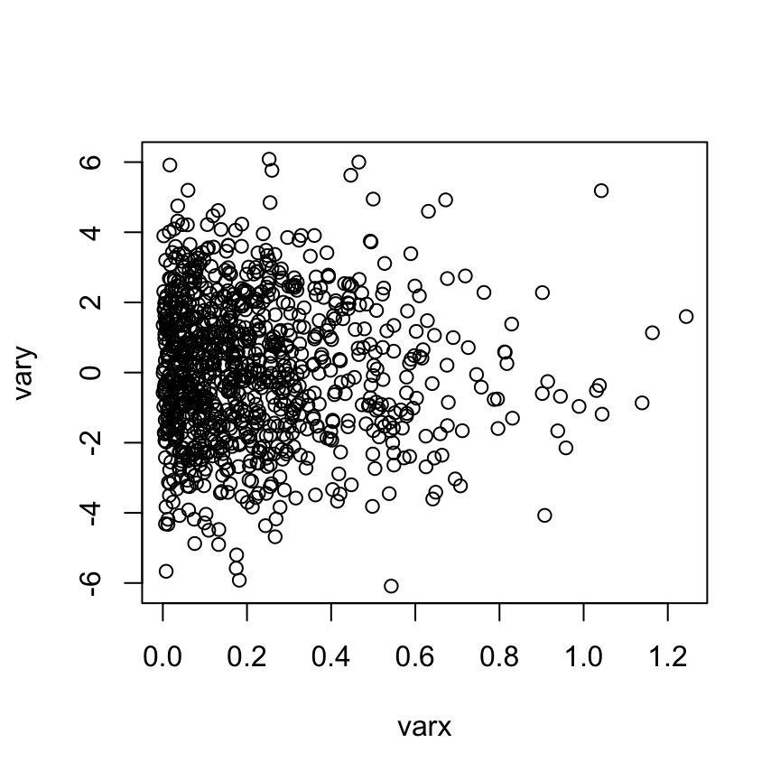

```r
varx <- rexp(n = 1000, rate = 5)
vary <- rnorm(n = 1000, mean = 0, sd = 2)
plot(varx, vary)
```

## Diagrama de dispersión

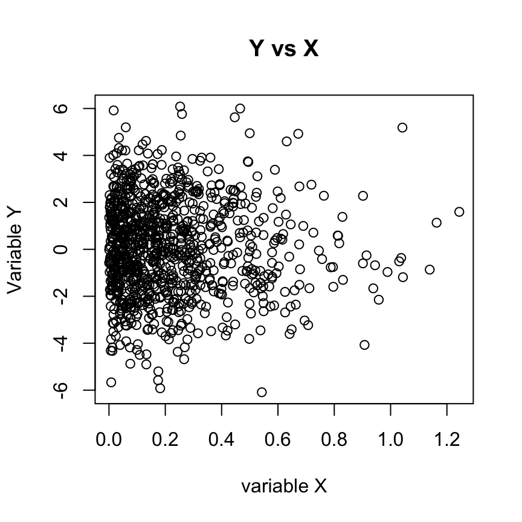

```r
plot(varx, vary, xlab = "variable X", ylab="Variable Y", main="Y vs X")
```

## Diagrama de dispersión

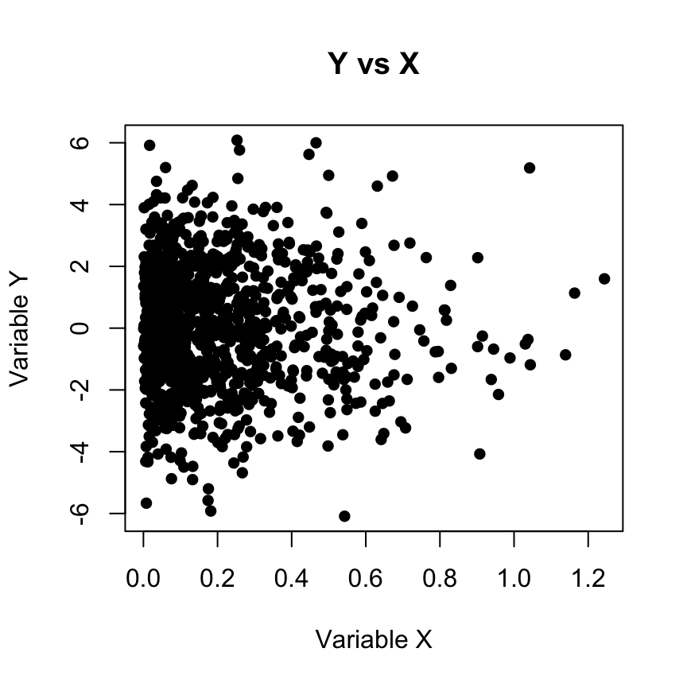

```r
plot(varx, vary, xlab = "Variable X", ylab="Variable Y", main="Y vs X",
     pch=16)
```

## Diagrama de dispersión

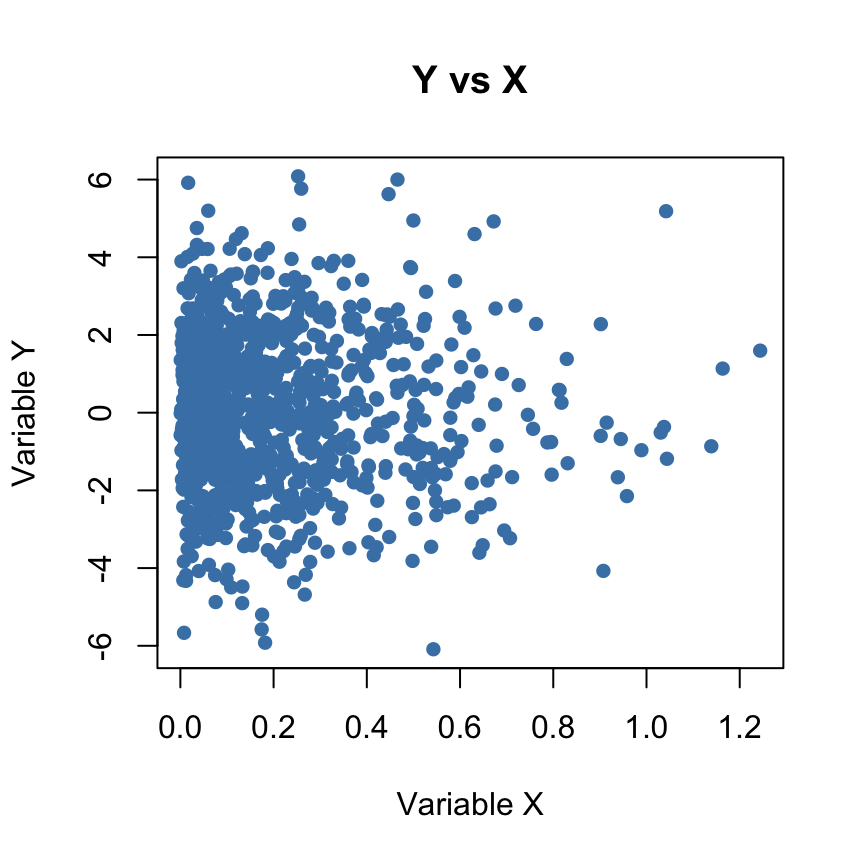

```r
plot(varx, vary, xlab = "Variable X", ylab="Variable Y", main="Y vs X",
     pch=16, col="steelblue")
```

## Diagrama de barras

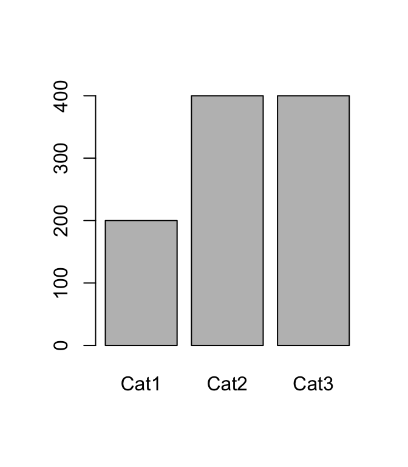

```r
varbp <- rep(c(1,2,2,3,3), 200)
varbp <- factor(varbp,levels = c(1,2,3), labels=c("Cat1", "Cat2", "Cat3"))
barplot(table(varbp))
```

## Diagrama de barras

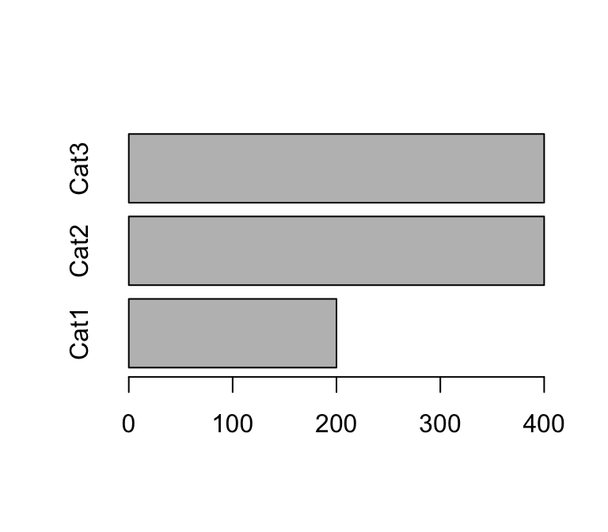

```r
barplot(table(varbp),horiz = TRUE)
```

## Diagrama de barras

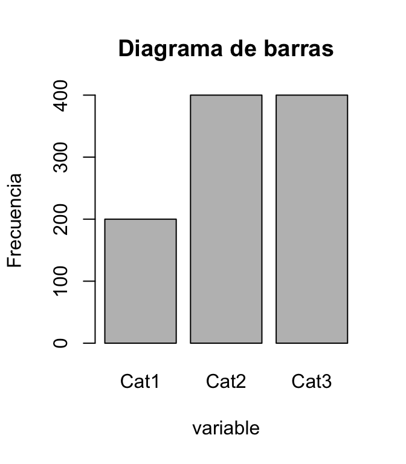

```r
barplot(table(varbp), xlab = "variable", ylab="Frecuencia", main="Diagrama de barras")
```

## Diagrama de barras

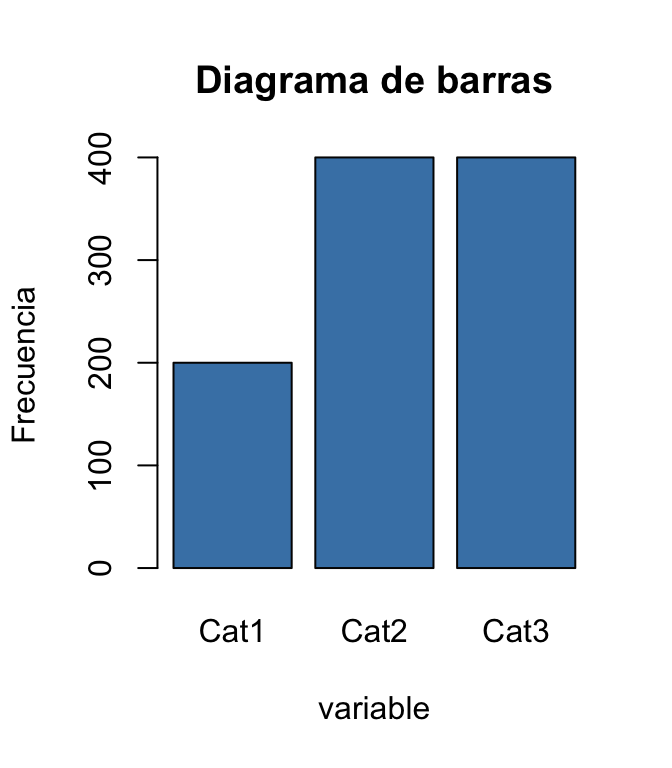

```r
barplot(table(varbp), xlab = "variable", ylab="Frecuencia", main="Diagrama de barras",
        col="steelblue", border="gray1")
```

## Múltiples gráficos

- Para imprimir varios gráficos, se utiliza el parámetro:
  - `par(mfrow=c(2,2))`.
  - se obtiene una matriz de gráficos que se llena por filas.

```r
par(mfrow=c(2,2))
hist(varh,breaks = 25, xlab = "variable", ylab="Frecuencia", main="Histograma",
     col="steelblue", border="gray60")
boxplot(varbx, xlab = "", ylab="variable", main="Diagrama de cajas",
        col="steelblue", border="gray60")
plot(varx, vary, xlab = "variable X", ylab="variable Y", main="Y vs X",
     pch=16, col="steelblue")
barplot(table(varbp), xlab = "variable", ylab="Frecuencia", main="Diagrama de barras",
        col="steelblue", border="gray50")
```

## Múltiples gráficos

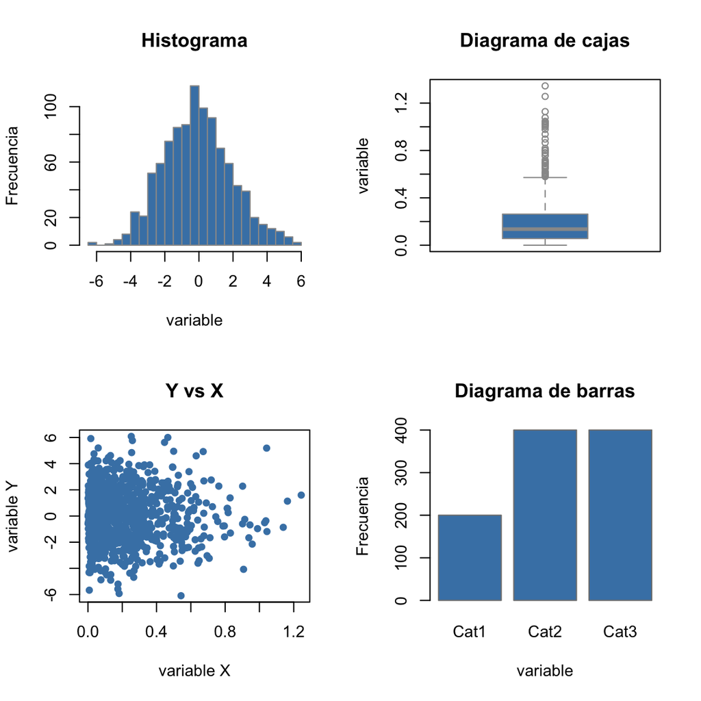

## Modelo gráfico paleta de artista

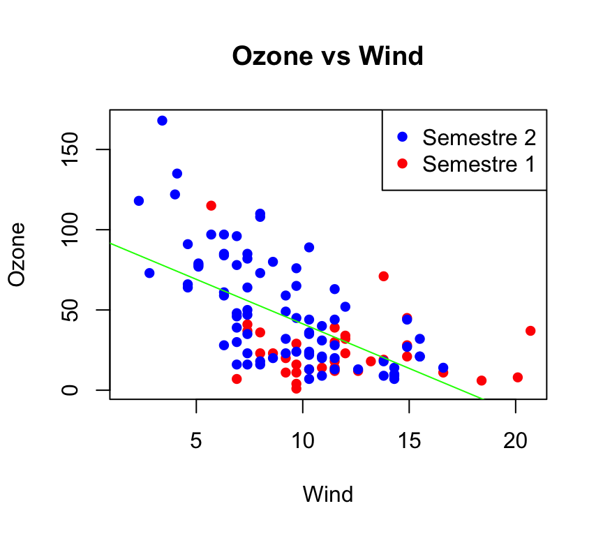

```r
with(airquality, plot(Wind, Ozone, main = "Ozone vs Wind", type = "n"))
with(subset(airquality, Month <= 6), points(Wind, Ozone, col = "red", pch=16))
with(subset(airquality, Month > 6), points(Wind, Ozone, col = "blue", pch=16))
model <- lm(Ozone ~ Wind, airquality)
abline(model, lwd = 1, col= "green")
legend("topright", pch = 16, col = c("blue", "red"),legend = c("Semestre 2", "Semestre 1"))
```

## Ejercicio

- Lea el archivo de datos `data.txt`.
- Realice los gráficos anteriores para las variables
  - Antiguedad
  - Estado_civil.
- Eliga los colores y titulos a conveniencia.

## Preguntas

[figure not shown]